# Practical Machine Learning Assignment

Charlotta Holm

December 11th, 2016

We start by loading the packages we need and reading in the data:

```r
setwd("~/Data Science/PML/Week 4")
library(caret)
library(dplyr)
```

```r
train <- read.csv("https://d396qusza40orc.cloudfront.net/predmachlearn/pml-training.csv")
test <- read.csv("https://d396qusza40orc.cloudfront.net/predmachlearn/pml-testing.csv")
```

Exploring the data we see that the train and test data have the same variables except for the last one, that is “classe” in the train set and “problem_id” in the test data.

The variabel we are trying to predict is the classe variable. A indicates that the Unilateral Dumbbell Biceps Curl was performed exactly according to the specification, B that the elbows were thrown to the front, C that the dumbbell was lifted only halfway, D that the dumbbell was lowered only halfway E that the hips were thrown to the front.

In the training data there are the following amounts of different types of excetions:

```r
summary(train$classe)
```

```
##    A    B    C    D    E
## 5580 3797 3422 3216 3607
```

## Preprocessing the data and selecting predictors

We’ll examine the variables further too decide which to include in the model.

Many of the 160 variables are partially filled with NA’s and/or empty. It seems that the variables with only partial information contain data only for rows with aggregated values. For the prediction we would want to use only raw data from the different sensors. Hence, we decide to exclude the aggregated data. But as the data set is very large, we decide to create a model using only the total acceleration values for the different sensors (arm, belt, forearm, dumbbell) and thus reduce the amount of variables further even though this is a trade off for accuracy of the model.

```r
var_incl <- c(grep("^total", names(train)),
              grep("^classe", names(train)))


train2 <- train[, c(var_incl)]
```

Now we get a df of 5 variables, one of which is the variable “classe” that we want to predict.

Next we want to check the variables to see if any of them show any correlation to the variable we want to predict or any outliers etc. We’ll do this by plotting a feature plot of the four predictor variables against the classe variable:

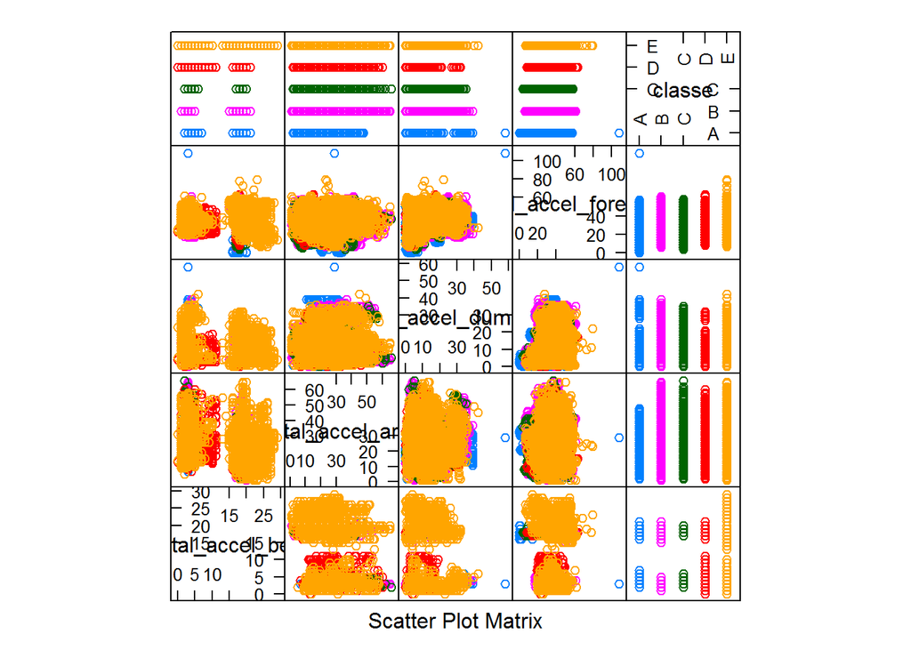

```r
featurePlot(train2, train2$classe, plot="pairs")
```

The graphs don’t show any particular correlations between the predictors and the variable classe, hence, we will continue with all variables.

```r
nz <- nearZeroVar(train2[, -53], saveMetric = TRUE)
```

We will use the random forest method which is an ensemble method, i.e. using multiple algorithms, hence no prior cross validation is needed. The cross validation is accounted for by the fact that the random forest averages many decision trees that are trained on different parts of the data.

```r
## OBS! Runs for very long => Use cache = TRUE
##modFit <- train(classe ~ ., data=train2, method="rf",prox=TRUE)
##modFit
##modFit$results[2]
##acc <- modFit$results[2]
```

```r
##pred <- predict(modFit, test)
## test$predRight <- pred==test$problem_id ## assigning the predicted value to a
##table(pred, test$problem_id) ## Table to show the predicted values cross tabulated with the real values.
```